# NRSG 736 Homework 2 - Answer Key

Melinda Higgins

10-04-2025

## Get quick summary of the groups (suicide yes or no)

Let’s compare people who did or did not have thoughts of suicide in the last 30 days at their baseline visit (`g1b`).

Get quick table of the counts and percents for suicidal thoughts yes vs no.

```r
# I used gtsummary here
h1 %>%
  select(g1b) %>%
  mutate(g1b = haven::as_factor(g1b)) %>%
  gtsummary::tbl_summary(
    type = list(g1b ~ "categorical")
  ) %>%
  modify_caption("**Table Using `gtsummary`**")
```

**Table Using `gtsummary`**

| **Characteristic** | **N = 453**<sup>1</sup> |
| --- | --- |
| g1b |  |
| no | 326 (72%) |
| yes | 127 (28%) |

<sup>1</sup> n (%)

```r
# alternative use table with knitr::kable
table(helpdat$g1b,
      useNA = "ifany") %>%
  knitr::kable(
    caption = "Alternative Table Using `table()` and `knitr`"
  )
```

Alternative Table Using `table()` and `knitr`

| Var1 | Freq |
| --- | --- |
| no | 326 |
| yes | 127 |

Notice that there are 326 who did NOT have thoughts of suicide and 127 who did (YES).

## Considering distributions

Before we summarize our data, we need to consider the distribution of the data - is it reasonably normally distributed? are there any obvious/major outliers?

For this I’ll provide the code here using `base R` and the `car` package. Let’s look at histograms with overlaid density curves AND look at Q-Q normal probability plots.

We can also formally run tests of the normal distribution assumption - the Shapiro-Wilks test.

The code below shows examples for `age` (which is fairly normally distributed) and for `d1` which is a count variable and highly right-skewed.

*I am not showing the distribution checks for all of the variables here.*

### Histograms with overlaid density curve

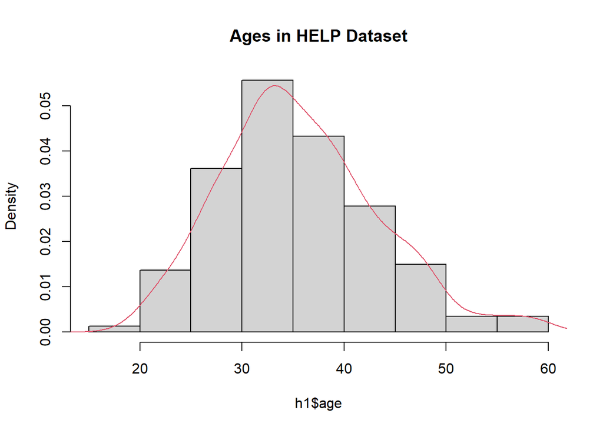

```r
hist(h1$age, probability = T,
     main = "Ages in HELP Dataset")
lines(density(h1$age), col=2)
```

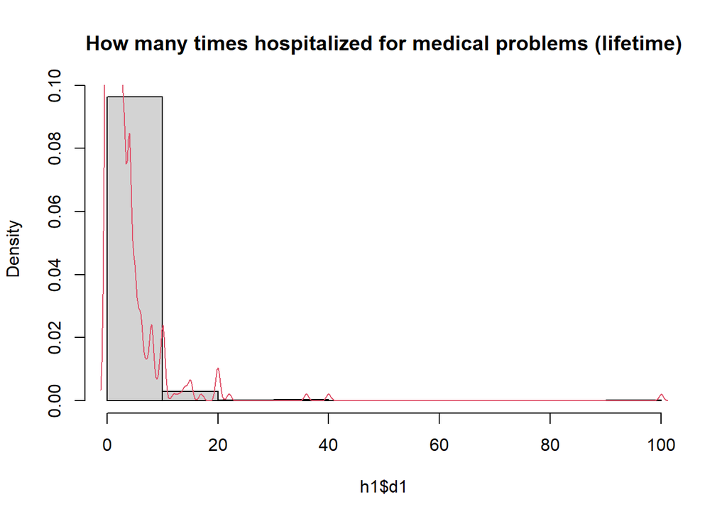

```r
hist(h1$d1, probability = T,
     main = "How many times hospitalized for medical problems (lifetime)")
lines(density(h1$d1), col=2)
```

### Q-Q plot with `base R`

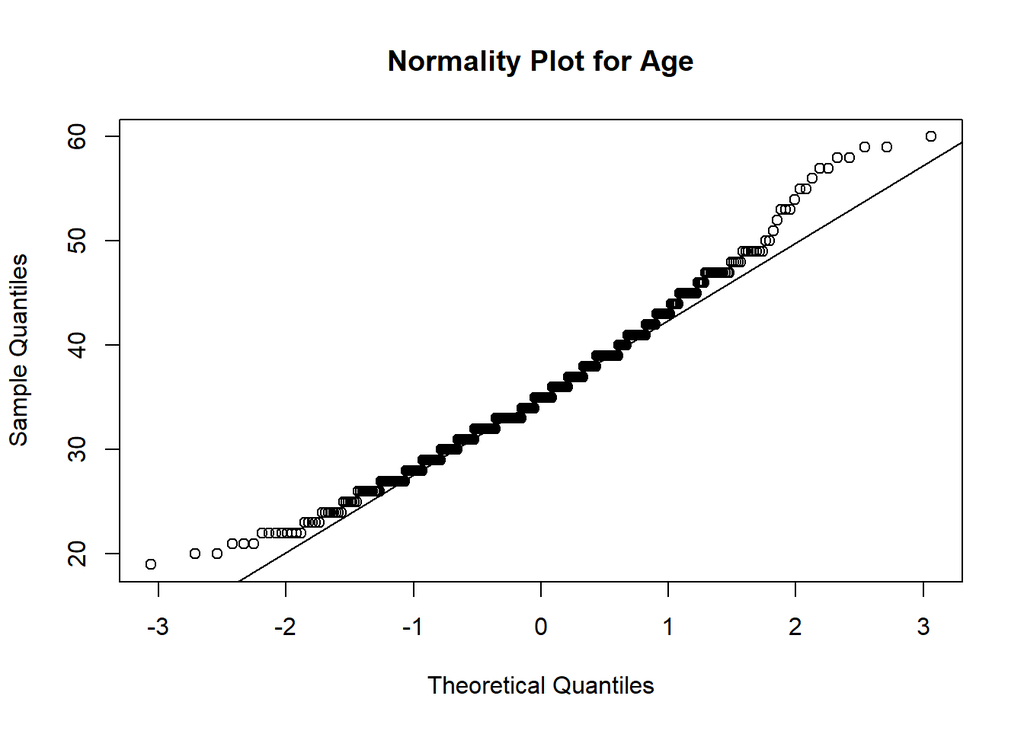

```r
# add QQ plot and reference line
qqnorm(h1$age,
       main = "Normality Plot for Age")
qqline(h1$age)
```

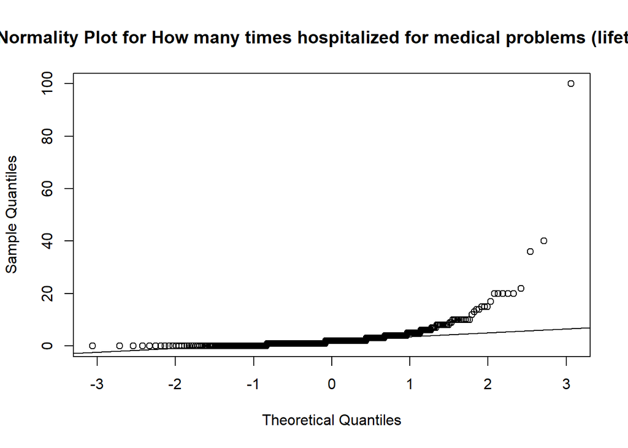

```r
# add QQ plot and reference line
qqnorm(h1$d1,
       main = "Normality Plot for How many times hospitalized for medical problems (lifetime)")
qqline(h1$d1)
```

### Q-Q plot with `car::qqPlot()` - with shaded confidence intervals

Using `qqPlot()` from the `car` (companion for applied regression) package by John Fox https://cran.r-project.org/web/packages/car/index.html, the potential outliers are highlighted by row number.

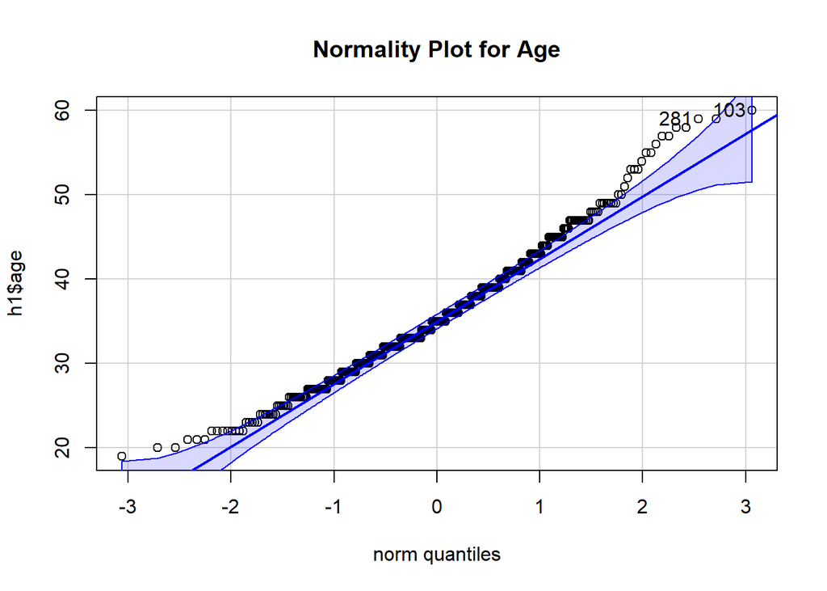

```
## [1] 103 281
```

```r
# QQ Plot using car package
car::qqPlot(h1$age,
            main = "Normality Plot for Age")
```

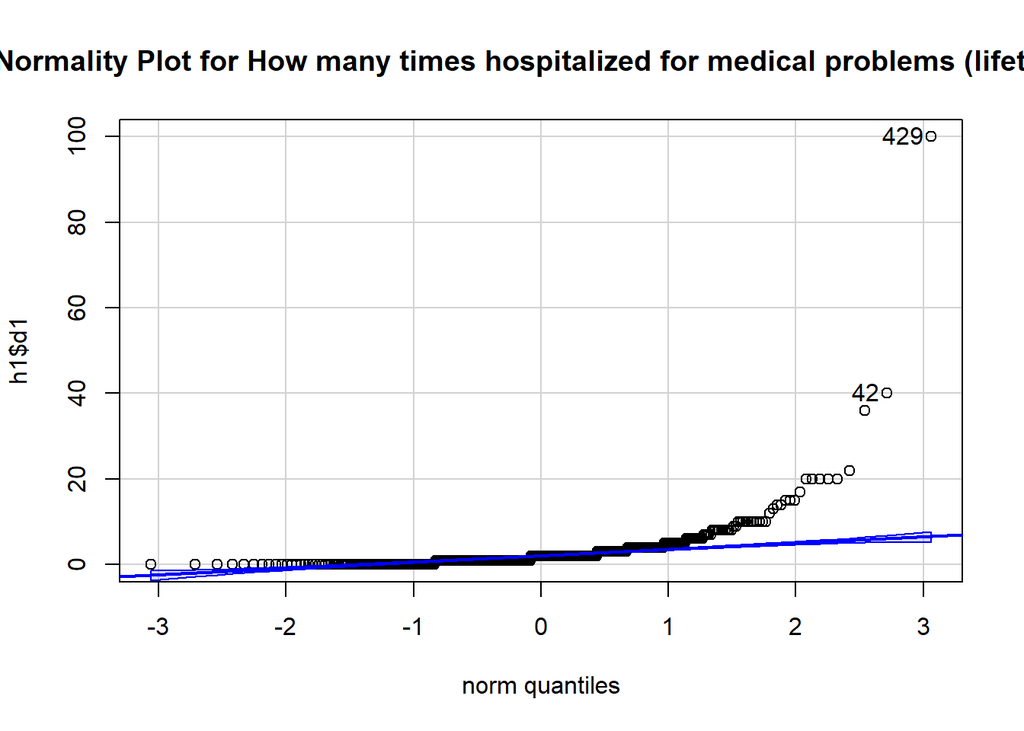

```
## [1] 429  42
```

```r
car::qqPlot(h1$d1,
            main = "Normality Plot for How many times hospitalized for medical problems (lifetime)")
```

### Shapiro-Wilks Normality Test

Both of these are statistically significant (see below), p < 0.05. However, the QQ Plot for `age` above is reasonably normally distributed whereas the one for `d1` which is a count variable for “How many times hospitalized for medical problems (lifetime)” is obviously skewed and non-normal.

**Remember that the Shapiro-Wilks (and similar) tests are sensitive for larger sample sizes, so even if the p-value is < 0.05, look at the QQ plots (normal probability plots) to assess whether or not the data look reasonably normal.**

Also check the means and medians and see if the values are similar and if the histogram is roughly symmetric - most statistical tests and models are reasonably robust to kurtosis issues (distribution is more pointy or flat when compared to the bell-shaped normal curve). The main issues to look for are skewness to the left or right (longer tails to the left or right).

```r
# shapiro-wilks normality test
shapiro.test(h1$age)
```

```
##
##  Shapiro-Wilk normality test
##
## data:  h1$age
## W = 0.98016, p-value = 7.438e-06
```

```r
shapiro.test(h1$d1)
```

```
##
##  Shapiro-Wilk normality test
##
## data:  h1$d1
## W = 0.38384, p-value < 2.2e-16
```

## Checking assumptions - equal variances for t-tests

The codes *above* for the Shapiro-Wilks tests show how to check the normality assumptions to help decide if we need to run parametric or non-parametric tests and associated descriptive statistics.

However, when we run a t-test, we also need to check the assumption or equal variance. To do this we should:

1. check the ratio of the 2 group standard deviations (ideally < than 2:1 ratio)
2. and perform the test of equal variance - here I’m using the base R function `bartlett.test()`.

Ratio of the 2 standard deviations - I’m using the `purrr::map()` function here. The code below is an example for the `age` variable and for the `g1b` suicide YES/NO group variable.

```r
library(purrr)
sd2grp <- h1 %>%
  split(.$g1b) %>%
  purrr::map(~sd(.$age))

# make data.frame
sd2grp.df <- data.frame(sd2grp)

# show this as a table
knitr::kable(sd2grp.df,
             col.names = c("SD for AGE for Suicide No",
                           "SD for AGE for Suicide Yes"),
             caption = "Standard Deviations for Age by Suicide YES/NO Group")
```

Standard Deviations for Age by Suicide YES/NO Group

| SD for AGE for Suicide No | SD for AGE for Suicide Yes |
| --- | --- |
| 7.781849 | 7.50915 |

```r
ratiosd <- ifelse(
  sd2grp.df[,1] > sd2grp.df[,2],
  sd2grp.df[,1] / sd2grp.df[,2],
  sd2grp.df[,2] / sd2grp.df[,1]
)

bt_age <- bartlett.test(age ~ g1b, data=h1)
```

For the `age` variable:

- The standard deviations for the two suicide YES/NO groups were 7.7818493 and 7.5091495, where the ratio was 1.0363157 which is < less than 2.
- The p-value for Bartlett’s test of equal variance was 0.6330372.

**NOTE: I am not showing the checks for all of the approximately normally distributed variables (`age`, `pss_fr`, `pcs`, `mcs`, `cesd`). However, as long as you provide the justification, I will accept either the pooled or unpooled t-tests.**

## Checking assumptions - small cell counts for Chi-square tests

When using the full HELP dataset, the EXPECTED counts are ok. I like using the `gmodels` package which has the `CrossTable()` function which will provide a warning if the expected counts assumption is not met (when using the `format = "SPSS"` option).

*The output below from the `gmodels` package shows the EXPECTED and ACTUAL counts - compare these!*

```r
# you can also see if there is a warning
# using the gmodels package
# with the SPSS format
library(gmodels)
gmodels::CrossTable(h1$racegrp, h1$g1b,
                    expected=TRUE,
                    prop.r=FALSE,
                    prop.t=FALSE,
                    prop.chisq=FALSE,
                    chisq=TRUE,
                    fisher=TRUE,
                    format = "SPSS")
```

```
##
##    Cell Contents
## |-------------------------|
## |                   Count |
## |         Expected Values |
## |          Column Percent |
## |-------------------------|
##
## Total Observations in Table:  453
##
##              | h1$g1b
##   h1$racegrp |       no  |      yes  | Row Total |
## -------------|-----------|-----------|-----------|
##     black    |      171  |       40  |      211  |
##              |  151.845  |   59.155  |           |
##              |   52.454% |   31.496% |           |
## -------------|-----------|-----------|-----------|
##     hispanic |       29  |       21  |       50  |
##              |   35.982  |   14.018  |           |
##              |    8.896% |   16.535% |           |
## -------------|-----------|-----------|-----------|
##     other    |       18  |        8  |       26  |
##              |   18.711  |    7.289  |           |
##              |    5.521% |    6.299% |           |
## -------------|-----------|-----------|-----------|
##     white    |      108  |       58  |      166  |
##              |  119.461  |   46.539  |           |
##              |   33.129% |   45.669% |           |
## -------------|-----------|-----------|-----------|
## Column Total |      326  |      127  |      453  |
##              |   71.965% |   28.035% |           |
## -------------|-----------|-----------|-----------|
##
##
## Statistics for All Table Factors
##
##
## Pearson's Chi-squared test
## ------------------------------------------------------------
## Chi^2 =  17.47008     d.f. =  3     p =  0.0005656105
##
##
##
## Fisher's Exact Test for Count Data
## ------------------------------------------------------------
## Alternative hypothesis: two.sided
## p =  0.0004368205
##
##
##        Minimum expected frequency: 7.289183
```

## Descriptive Stats Table - using `arsenal` package

Learn more on how to make these tables with the `arsenal` pacakge - read the vignette on the [`tableby` function](https://cran.r-project.org/web/packages/arsenal/vignettes/tableby.html).

Compare by `g1b` suicide YES/NO group.

Notice that I have used `anova()` for the normally distributed variables, `kwt()` for the non-normal/skewed variables, and either the `chisq()` Chi-square test or `fe()` Fisher’s exact test for the categorical variables.

Notice the inclusion of footnotes below.

```r
# use the attr() function
# to use labels on the variables
# age pss_fr pcs mcs cesd

attr(h1$age,'label')  <-
  attributes(h1)[["variable.labels"]][["age"]]
attr(h1$pss_fr,'label')  <-
  attributes(h1)[["variable.labels"]][["pss_fr"]]
attr(h1$pcs,'label')  <-
  attributes(h1)[["variable.labels"]][["pcs"]]
attr(h1$mcs,'label')  <-
  attributes(h1)[["variable.labels"]][["mcs"]]
attr(h1$cesd,'label')  <-
  attributes(h1)[["variable.labels"]][["cesd"]]

# a15a a15b d1 e2b i1 i2

attr(h1$a15a,'label')  <-
  attributes(h1)[["variable.labels"]][["a15a"]]
attr(h1$a15b,'label')  <-
  attributes(h1)[["variable.labels"]][["a15b"]]
attr(h1$d1,'label')  <-
  attributes(h1)[["variable.labels"]][["d1"]]
attr(h1$e2b,'label')  <-
  attributes(h1)[["variable.labels"]][["e2b"]]
attr(h1$i1,'label')  <-
  attributes(h1)[["variable.labels"]][["i1"]]
attr(h1$i2,'label')  <-
  attributes(h1)[["variable.labels"]][["i2"]]

# female racegrp homeless

attr(h1$female,'label')  <-
  attributes(h1)[["variable.labels"]][["female"]]
attr(h1$racegrp,'label')  <-
  attributes(h1)[["variable.labels"]][["racegrp"]]
attr(h1$homeless,'label')  <-
  attributes(h1)[["variable.labels"]][["homeless"]]

# make sure results = "asis" for chunk option
# custom statistics defined below

tb1 <- tableby(
  g1b ~
    # parametric stats
    anova(age, "Nmiss", "meansd") +
    anova(pss_fr, "Nmiss", "meansd") +
    anova(pcs, "Nmiss", "meansd") +
    anova(mcs, "Nmiss", "meansd") +
    anova(cesd, "Nmiss", "meansd") +
    # non-parametric stats
    kwt(a15a, "Nmiss", "medianq1q3") +
    kwt(a15b, "Nmiss", "medianq1q3") +
    kwt(d1, "Nmiss", "medianq1q3") +
    kwt(e2b, "Nmiss", "medianq1q3") +
    kwt(i1, "Nmiss", "medianq1q3") +
    kwt(i2, "Nmiss", "medianq1q3") +
    kwt(a15a, "Nmiss", "medianq1q3") +
    # categorical chi-square stats
    chisq(female, "Nmiss", "countpct") +
    chisq(racegrp, "Nmiss", "countpct") +
    chisq(homeless, "Nmiss", "countpct"),
  data = h1
)

# add footnotes for the different tests
summary(tb1,
        pfootnote = TRUE,
        title = "Compare Subject Characteristics by Suicide Group")
```

Compare Subject Characteristics by Suicide Group

|  | no (N=326) | yes (N=127) | Total (N=453) | p value |
| --- | --- | --- | --- | --- |
| **Age at baseline (in years)** |  |  |  | 0.233<sup>1</sup> |
| Mean (SD) | 35.923 (7.782) | 34.961 (7.509) | 35.653 (7.710) |  |
| **Perceived Social Support - friends** |  |  |  | 0.054<sup>1</sup> |
| Mean (SD) | 6.933 (4.046) | 6.126 (3.815) | 6.706 (3.995) |  |
| **SF36 Physical Composite Score - Baseline** |  |  |  | 0.002<sup>1</sup> |
| Mean (SD) | 49.041 (10.744) | 45.501 (10.507) | 48.049 (10.785) |  |
| **SF36 Mental Composite Score - Baseline** |  |  |  | < 0.001<sup>1</sup> |
| Mean (SD) | 34.203 (13.291) | 25.191 (8.764) | 31.677 (12.839) |  |
| **CESD total score - Baseline** |  |  |  | < 0.001<sup>1</sup> |
| Mean (SD) | 30.221 (12.466) | 39.591 (9.863) | 32.848 (12.514) |  |
| **Number of nights in overnigh shelter in past 6 months** |  |  |  | 0.166<sup>2</sup> |
| Median (Q1, Q3) | 0.000 (0.000, 2.000) | 0.000 (0.000, 4.500) | 0.000 (0.000, 3.000) |  |
| **Number of nights on the street in past 6 months** |  |  |  | 0.015<sup>2</sup> |
| Median (Q1, Q3) | 0.000 (0.000, 2.000) | 0.000 (0.000, 5.500) | 0.000 (0.000, 3.000) |  |
| **How many times hospitalized for medical problems (lifetime)** |  |  |  | < 0.001<sup>2</sup> |
| Median (Q1, Q3) | 1.000 (1.000, 3.000) | 2.000 (1.000, 5.000) | 2.000 (1.000, 3.000) |  |
| **Number of times in past 6 months entered a detox program - Baseline** |  |  |  | 0.220<sup>2</sup> |
| N-Miss | 182 | 57 | 239 |  |
| Median (Q1, Q3) | 2.000 (1.000, 3.000) | 2.000 (1.000, 3.000) | 2.000 (1.000, 3.000) |  |
| **Average number of drinks (standard units) consumed per day (in past 30 days) - Baseline** |  |  |  | 0.011<sup>2</sup> |
| Median (Q1, Q3) | 12.000 (3.000, 24.750) | 15.000 (3.500, 32.500) | 13.000 (3.000, 26.000) |  |
| **Maximum number of drinks (standard units) consumed per day (in past 30 days)** |  |  |  | 0.002<sup>2</sup> |
| Median (Q1, Q3) | 13.000 (2.000, 26.000) | 24.000 (4.500, 41.500) | 15.000 (3.000, 32.000) |  |
| **Gender of respondent** |  |  |  | 0.001<sup>3</sup> |
| Male | 262 (80.4%) | 84 (66.1%) | 346 (76.4%) |  |
| Female | 64 (19.6%) | 43 (33.9%) | 107 (23.6%) |  |
| **Racial Group of Respondent** |  |  |  | < 0.001<sup>3</sup> |
| black | 171 (52.5%) | 40 (31.5%) | 211 (46.6%) |  |
| hispanic | 29 (8.9%) | 21 (16.5%) | 50 (11.0%) |  |
| other | 18 (5.5%) | 8 (6.3%) | 26 (5.7%) |  |
| white | 108 (33.1%) | 58 (45.7%) | 166 (36.6%) |  |
| **One or more nights on the street or shelter in past 6 months** |  |  |  | 0.005<sup>3</sup> |
| no | 189 (58.0%) | 55 (43.3%) | 244 (53.9%) |  |
| yes | 137 (42.0%) | 72 (56.7%) | 209 (46.1%) |  |

1. Linear Model ANOVA
2. Kruskal-Wallis rank sum test
3. Pearson’s Chi-squared test

Example with `gtsummary` package

```r
# useful in Rmarkdown
# also makes an HTML table
# gtsummary package
# gtsummary package already loaded above
library(gtsummary)

h1 %>%
  tbl_summary(
    by = g1b,
    label = list(
      age = attributes(h1)[["variable.labels"]][["age"]],
      pss_fr = attributes(h1)[["variable.labels"]][["pss_fr"]],
      pcs = attributes(h1)[["variable.labels"]][["pcs"]],
      mcs = attributes(h1)[["variable.labels"]][["mcs"]],
      cesd = attributes(h1)[["variable.labels"]][["cesd"]],
      a15a = attributes(h1)[["variable.labels"]][["a15a"]],
      a15b = attributes(h1)[["variable.labels"]][["a15b"]],
      d1 = attributes(h1)[["variable.labels"]][["d1"]],
      e2b = attributes(h1)[["variable.labels"]][["e2b"]],
      i1 = attributes(h1)[["variable.labels"]][["i1"]],
      i2 = attributes(h1)[["variable.labels"]][["i2"]],
      female = attributes(h1)[["variable.labels"]][["female"]],
      racegrp = attributes(h1)[["variable.labels"]][["racegrp"]],
      homeless = attributes(h1)[["variable.labels"]][["homeless"]]
    ),
    type = list(
      c(age, pss_fr, pcs, mcs, cesd) ~ "continuous",
      c(a15a, a15b, d1, e2b, i1, i2) ~ "continuous2",
      c(female, racegrp, homeless) ~ "categorical"
    ),
    digits = list(
      all_continuous() ~ 2,
      all_continuous2() ~ 2,
      all_categorical() ~ 1
    ),
    statistic = list(
      all_continuous() ~ "{mean} ({sd})",
      all_continuous2() ~ "{median} [{p25}, {p75}]",
      all_categorical() ~ "{n} ({p}%)"
    )
  ) %>%
  add_p(pvalue_fun = label_style_pvalue(digits = 3),
        test = list(all_continuous() ~ "t.test",
                    all_continuous2() ~ "wilcox.test",
                    all_categorical() ~ "chisq.test"))
```

| **Characteristic** | **no** N = 326<sup>1</sup> | **yes** N = 127<sup>1</sup> | **p-value**<sup>2</sup> |
| --- | --- | --- | --- |
| Age at baseline (in years) | 35.92 (7.78) | 34.96 (7.51) | 0.226 |
| Perceived Social Support - friends | 6.93 (4.05) | 6.13 (3.82) | 0.048 |
| SF36 Physical Composite Score - Baseline | 49.04 (10.74) | 45.50 (10.51) | 0.002 |
| SF36 Mental Composite Score - Baseline | 34.20 (13.29) | 25.19 (8.76) | <0.001 |
| CESD total score - Baseline | 30.22 (12.47) | 39.59 (9.86) | <0.001 |
| Number of nights in overnigh shelter in past 6 months |  |  | 0.166 |
| Median [Q1, Q3] | 0.00 [0.00, 2.00] | 0.00 [0.00, 5.00] |  |
| Number of nights on the street in past 6 months |  |  | 0.015 |
| Median [Q1, Q3] | 0.00 [0.00, 2.00] | 0.00 [0.00, 6.00] |  |
| How many times hospitalized for medical problems (lifetime) |  |  | <0.001 |
| Median [Q1, Q3] | 1.00 [1.00, 3.00] | 2.00 [1.00, 5.00] |  |
| Number of times in past 6 months entered a detox program - Baseline |  |  | 0.220 |
| Median [Q1, Q3] | 2.00 [1.00, 3.00] | 2.00 [1.00, 3.00] |  |
| Unknown | 182 | 57 |  |
| Average number of drinks (standard units) consumed per day (in past 30 days) - Baseline |  |  | 0.011 |
| Median [Q1, Q3] | 12.00 [3.00, 25.00] | 15.00 [3.00, 33.00] |  |
| Maximum number of drinks (standard units) consumed per day (in past 30 days) |  |  | 0.002 |
| Median [Q1, Q3] | 13.00 [2.00, 26.00] | 24.00 [4.00, 42.00] |  |
| Gender of respondent |  |  | 0.002 |
| Male | 262.0 (80.4%) | 84.0 (66.1%) |  |
| Female | 64.0 (19.6%) | 43.0 (33.9%) |  |
| Racial Group of Respondent |  |  | <0.001 |
| black | 171.0 (52.5%) | 40.0 (31.5%) |  |
| hispanic | 29.0 (8.9%) | 21.0 (16.5%) |  |
| other | 18.0 (5.5%) | 8.0 (6.3%) |  |
| white | 108.0 (33.1%) | 58.0 (45.7%) |  |
| One or more nights on the street or shelter in past 6 months |  |  | 0.007 |
| no | 189.0 (58.0%) | 55.0 (43.3%) |  |
| yes | 137.0 (42.0%) | 72.0 (56.7%) |  |

<sup>1</sup> Mean (SD); n (%)  
<sup>2</sup> Welch Two Sample t-test; Wilcoxon rank sum test; Pearson’s Chi-squared test

Add effect sizes to table

```r
# create custom functions
# to compute each effect size
my_escd <- function(data, variable, by, ...) {
  effectsize::cohens_d(data[[variable]] ~ as.factor(data[[by]]),
                       pooled_sd = TRUE,
                       paired = FALSE,
                       data = data) |>
    as.data.frame() %>%
    dplyr::mutate(
      stat = glue::glue(
        "d={style_sigfig(Cohens_d, digits = 3)},
        [{style_sigfig(CI_low, digits = 3)}, {style_sigfig(CI_high, digits = 3)}]"
        )
    ) %>%
    dplyr::pull(stat)
}

my_estau <- function(data, variable, by, ...) {
  correlation::correlation(
    data = data.frame(h1[[variable]],
                      as.numeric(h1[[by]])),
    method = "kendall") %>%
    as.data.frame() %>%
    dplyr::mutate(
      stat = glue::glue(
        "tau={style_sigfig(tau, digits = 3)},
        [{style_sigfig(CI_low, digits = 3)}, {style_sigfig(CI_high, digits = 3)}]"
      )
    ) %>%
    dplyr::pull(stat)
}

my_escw <- function(data, variable, by, ...) {
  table(h1[[variable]], h1[[by]]) %>%
  effectsize::cohens_w() %>%
  as.data.frame() %>%
    dplyr::mutate(
      stat = glue::glue(
        "w={style_sigfig(Cohens_w, digits = 3)},
        [{style_sigfig(CI_low, digits = 3)}, {style_sigfig(CI_high, digits = 3)}]"
      )
    ) %>%
    dplyr::pull(stat)
}
```

```r
h1 %>%
  tbl_summary(
    by = g1b,
    label = list(
      age = attributes(h1)[["variable.labels"]][["age"]],
      pss_fr = attributes(h1)[["variable.labels"]][["pss_fr"]],
      pcs = attributes(h1)[["variable.labels"]][["pcs"]],
      mcs = attributes(h1)[["variable.labels"]][["mcs"]],
      cesd = attributes(h1)[["variable.labels"]][["cesd"]],
      a15a = attributes(h1)[["variable.labels"]][["a15a"]],
      a15b = attributes(h1)[["variable.labels"]][["a15b"]],
      d1 = attributes(h1)[["variable.labels"]][["d1"]],
      e2b = attributes(h1)[["variable.labels"]][["e2b"]],
      i1 = attributes(h1)[["variable.labels"]][["i1"]],
      i2 = attributes(h1)[["variable.labels"]][["i2"]],
      female = attributes(h1)[["variable.labels"]][["female"]],
      racegrp = attributes(h1)[["variable.labels"]][["racegrp"]],
      homeless = attributes(h1)[["variable.labels"]][["homeless"]]
    ),
    type = list(
      c(age, pss_fr, pcs, mcs, cesd) ~ "continuous",
      c(a15a, a15b, d1, e2b, i1, i2) ~ "continuous2",
      c(female, racegrp, homeless) ~ "categorical"
    ),
    digits = list(
      all_continuous() ~ 2,
      all_continuous2() ~ 2,
      all_categorical() ~ 1
    ),
    statistic = list(
      all_continuous() ~ "{mean} ({sd})",
      all_continuous2() ~ "{median} [{p25}, {p75}]",
      all_categorical() ~ "{n} ({p}%)"
    )
  ) %>%
  add_p(pvalue_fun = label_style_pvalue(digits = 3),
        test = list(all_continuous() ~ "t.test",
                    all_continuous2() ~ "wilcox.test",
                    all_categorical() ~ "chisq.test")) %>%
  add_stat(fns = list(all_continuous() ~ my_escd,
                      all_continuous2() ~ my_estau,
                      all_categorical() ~ my_escw)) |>
  modify_header(add_stat_1 = "**Effect Size**")
```

| **Characteristic** | **no** N = 326<sup>1</sup> | **yes** N = 127<sup>1</sup> | **p-value**<sup>2</sup> | **Effect Size** |
| --- | --- | --- | --- | --- |
| Age at baseline (in years) | 35.92 (7.78) | 34.96 (7.51) | 0.226 | d=0.125, [-0.080, 0.330] |
| Perceived Social Support - friends | 6.93 (4.05) | 6.13 (3.82) | 0.048 | d=0.202, [-0.003, 0.408] |
| SF36 Physical Composite Score - Baseline | 49.04 (10.74) | 45.50 (10.51) | 0.002 | d=0.331, [0.125, 0.537] |
| SF36 Mental Composite Score - Baseline | 34.20 (13.29) | 25.19 (8.76) | <0.001 | d=0.739, [0.528, 0.949] |
| CESD total score - Baseline | 30.22 (12.47) | 39.59 (9.86) | <0.001 | d=-0.794, [-1.01, -0.582] |
| Number of nights in overnigh shelter in past 6 months |  |  | 0.166 | tau=0.060, [-0.001, 0.121] |
| Median [Q1, Q3] | 0.00 [0.00, 2.00] | 0.00 [0.00, 5.00] |  |  |
| Number of nights on the street in past 6 months |  |  | 0.015 | tau=0.106, [0.045, 0.166] |
| Median [Q1, Q3] | 0.00 [0.00, 2.00] | 0.00 [0.00, 6.00] |  |  |
| How many times hospitalized for medical problems (lifetime) |  |  | <0.001 | tau=0.160, [0.100, 0.219] |
| Median [Q1, Q3] | 1.00 [1.00, 3.00] | 2.00 [1.00, 5.00] |  |  |
| Number of times in past 6 months entered a detox program - Baseline |  |  | 0.220 | tau=0.077, [-0.013, 0.165] |
| Median [Q1, Q3] | 2.00 [1.00, 3.00] | 2.00 [1.00, 3.00] |  |  |
| Unknown | 182 | 57 |  |  |
| Average number of drinks (standard units) consumed per day (in past 30 days) - Baseline |  |  | 0.011 | tau=0.100, [0.039, 0.160] |
| Median [Q1, Q3] | 12.00 [3.00, 25.00] | 15.00 [3.00, 33.00] |  |  |
| Maximum number of drinks (standard units) consumed per day (in past 30 days) |  |  | 0.002 | tau=0.122, [0.062, 0.182] |
| Median [Q1, Q3] | 13.00 [2.00, 26.00] | 24.00 [4.00, 42.00] |  |  |
| Gender of respondent |  |  | 0.002 | w=0.150, [0.073, 1.00] |
| Male | 262.0 (80.4%) | 84.0 (66.1%) |  |  |
| Female | 64.0 (19.6%) | 43.0 (33.9%) |  |  |
| Racial Group of Respondent |  |  | <0.001 | w=0.196, [0.104, 1.00] |
| black | 171.0 (52.5%) | 40.0 (31.5%) |  |  |
| hispanic | 29.0 (8.9%) | 21.0 (16.5%) |  |  |
| other | 18.0 (5.5%) | 8.0 (6.3%) |  |  |
| white | 108.0 (33.1%) | 58.0 (45.7%) |  |  |
| One or more nights on the street or shelter in past 6 months |  |  | 0.007 | w=0.132, [0.055, 1.00] |
| no | 189.0 (58.0%) | 55.0 (43.3%) |  |  |
| yes | 137.0 (42.0%) | 72.0 (56.7%) |  |  |

<sup>1</sup> Mean (SD); n (%)  
<sup>2</sup> Welch Two Sample t-test; Wilcoxon rank sum test; Pearson’s Chi-squared test

```r
# h1 %>%
#   tbl_summary(
#     by = g1b,
#     label = list(
#       age = "Age in years",
#       mcs = "Mental Component Score - SF36 QOL",
#       a15a = "In the last 6m how many nights have you spentin an overnight shelter",
#       d1 = "How many times hospitalized for medical problems (lifetime)",
#       e2b = "Number of times in past 6 months entered a detox program",
#       racegrp = "Race"),
#     type = list(
#       c(age, mcs) ~ "continuous",
#       c(a15a, d1, e2b) ~ "continuous2",
#       c(racegrp) ~ "categorical"
#     ),
#     digits = list(
#       all_continuous() ~ 2,
#       all_continuous2() ~ 2,
#       all_categorical() ~ 1
#     ),
#     statistic = list(
#       all_continuous() ~ "{mean} ({sd})",
#       all_continuous2() ~ "{median} [{p25}, {p75}]",
#       all_categorical() ~ "{n} ({p}%)"
#     )
#   ) %>%
#   add_p(pvalue_fun = label_style_pvalue(digits = 3),
#         test = list(all_continuous() ~ "t.test",
#                     all_continuous2() ~ "wilcox.test",
#                     all_categorical() ~ "chisq.test")) %>%
#   add_stat(fns = list(all_continuous() ~ my_escd,
#                       all_continuous2() ~ my_estau,
#                       all_categorical() ~ my_escw)) |>
#   modify_header(add_stat_1 = "**Effect Size**")
```